# EDA Project by Henrik Steffen

### Plot Two

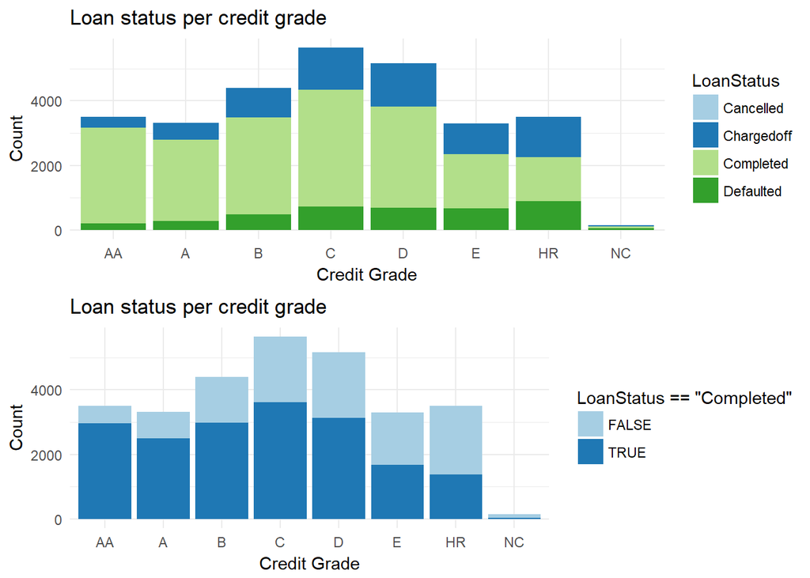

### Description Two

In this analysis I often assumed that the rating of a loan is an indicator for the risk the lender has to bear. This plot shows that a worse rating is associated with a higher risk of the loan being either “Defaulted” or “Chargedoff”. Put in another way, the ratio of loans that are completed decreses from the best to the worst rating.

### Plot Three

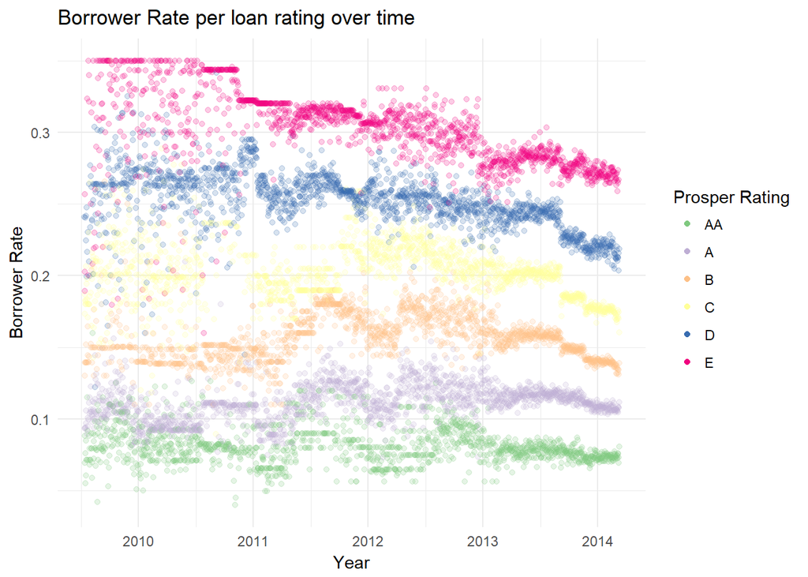

# Reflection

This dataset contains more than 100 000 observations with 81 variables. I started by looking at some variables that I found interesting and explored them. With that many variables, I could not look at every single one and probably missed some interesting ones, and subsequently probably missed some interesting relationships between them.

I found that at some point in time a new rating system for loans was introduced (this would have been obvious had I read the variables definition earlier). I looked at the income ranges of the customers and found that a significant portion are high income (>75.000$) customers. Surprisingly to me those high income customers took out loans for the purpose of debt consolidation as frequently as lower income customers.

The variables I was most interest in were the rating of the loans, the number of investors per loan, the BorrowerRate/LenderYield, the monthly payment and income, the loaned amount and the loan status. I found several relationships between those variables. The rating of a loan for example relates to the number of investors funding a loan, i.e. the number of investors decreases from the best to the worst rating. The borrower rate (and lender yield) is also in realtionship with the rating of a loan, as it increases from best to worst rating. I also looked at what factors might determine the rating of a loan, and found that the IncomeRange might be a suitable candidate. From the best to the worst rating, the proportion of high income customers decreases, while the proportion of lower income customers increases. This hints at the income being a determining factor for the rating of a loan.

I also assumed that the ratingof a loan indicates the risk associated with a loan, meaning that loans with a worse rating are riskier for the lender. By plotting the LoanStatus per rating I showed that the portion of, in one way or another, not completed loans increases from the best to the worst rating. At the same time the BorrowerRate and LenderYield also increase from loans with the best to ones with the worst rating. Meaning that as the risk for a lender increases with worse ratings, the possible yield also increases. For customers this means that they have to pay higher interest rates for loans with a worse rating.

I also found nearly linear relationships between the monthly payment and the overall amount loaned, which is not very surprising. There are 3 subsets within monthly payment determined by the term of a loan. This means that customers have to pay different monthly amounts for the same overall amount they loaned depending on how long the loan runs. This would be a good candidate to develop a linear model to predict the monthly payment depending on the overall amount and the term.

I also looked at the BorrowerRate over time and found that there is a gap between October 2008 and April 2009 when no new loans where issued. In this case it would be interesting to look at some historical events such as the collapse of Lehman Brothers, which might be a possible explanation. Furthermore it would be interesting to plot the Federal Funds Rate (set by the FED) and compare it to the interest rate observed in this dataset.

Overall with this dataset I found it difficult to get an overview over which of all these variables might be interesting. Some of these variables are also quite similar to each other, e.g. there are multiple different income variables, two different rating systems and multiple variables for open credit lines and so on. Also the introduction of a new rating system in 2009 made it difficult to relate variables to the rating over the whole course of time.

My idea for further analysis of this dataset centers around comparisons with additional datasets. For example one could look at general economic parameters of the U.S.like unemployment, GDP, economic growth rate, wage development, No. of businesses going bankrupt etc. in order to see whether there is a relationship between these more general (national) parameters and the variables in this dataset. One could try find out whether there is a relationship between the overall economic situation and the number of loans taken out. Or is the amount loaned affected by the general development of the wages? Overall it would be interesting to put this loan dataset into a broader economic context.

## References

http://ggplot2.tidyverse.org/reference/guide_legend.html http://www.sthda.com/english/wiki/ggplot2-histogram-plot-quick-start-guide-r-software-and-data-visualization https://stackoverflow.com/questions/28755576/add-text-to-ggplot http://www.cookbook-r.com/Graphs/Colors_(ggplot2)/ https://www.r-bloggers.com/how-to-expand-color-palette-with-ggplot-and-rcolorbrewer/ http://ggplot2.tidyverse.org/reference/ggtheme.html